# Impacto del proceso de vacunación contra la Covid-19

Mauricio Rodriguez, Renato Rodriguez, Sebastian Quispe, Christian Salazar, Frings Barrueta

June 9th 2021

#Instalacion de librerias

```r
install.packages("readr")
install.packages("dplyr")
```

```r
install.packages ("ggplot2")
install.packages("stringr")
install.packages("scales")
install.packages("lubridate")
install.packages("modeest")
install.packages("viridis")
```

# Cargar librerias

```r
library(readr)
library(dplyr)
```

```r
library (ggplot2)
library(stringr)
library(scales)
library(lubridate)
library(modeest)
library(viridis)
library(lubridate)
```

Utilies

```r
# Verifica si es que la variable es integer(0) o no
fun_int0 <- function(my_data) {    # Create user-defined function

  if(length(my_data) == 0 & is.integer(my_data)) {

    return(FALSE)
# [1] "The data object is integer(0)."

  } else {

    return(TRUE)
# [1] "The data object is NOT integer(0)."
  }
}
```

# Asignar DF’s con los datos RAW de los archivos

```r
DFFallecidosRAW <- read_csv("fallecidos.csv")
DFVacunadosRAW <- read_csv("vacunados.csv")
```

# Limpieza tabla DFFallecidos

# Limpieza tabla DFVacunados

# Figuras de Mérito

## Dataset FALLECIDOS

### FECHA_FALLECIMIENTO

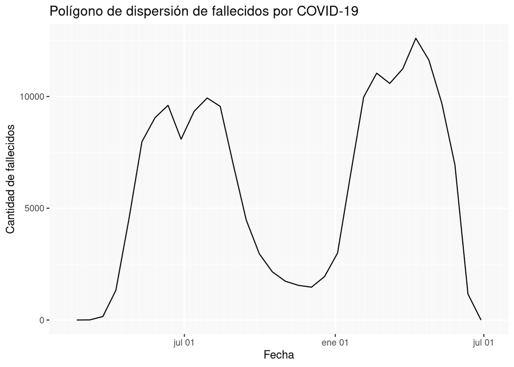

### EDAD

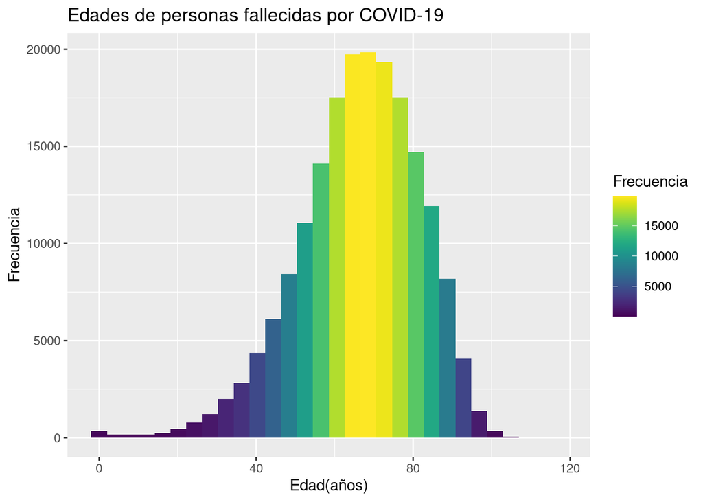

### SEXO

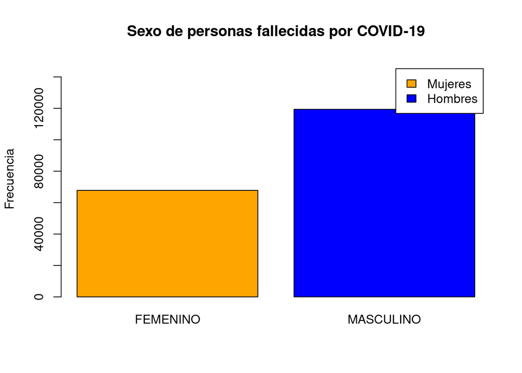

### DEPARTAMENTO

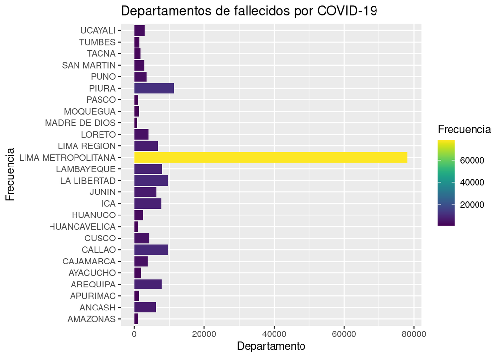

## Dataset PROCESO DE VACUNACIÓN

### SEXO

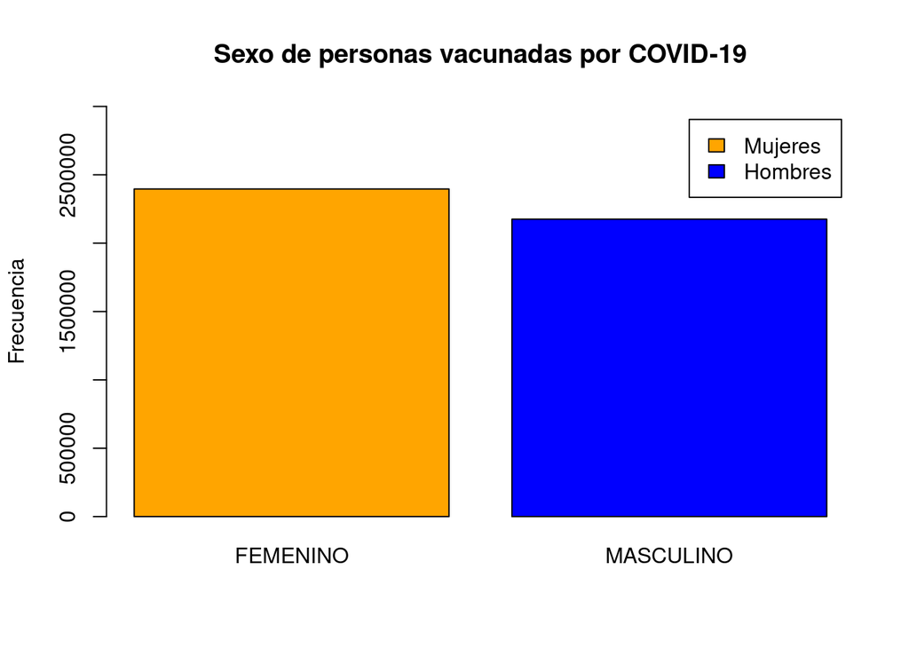

### DOSIS

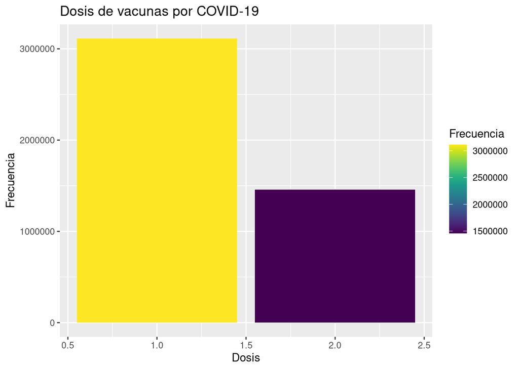

### FABRICANTE

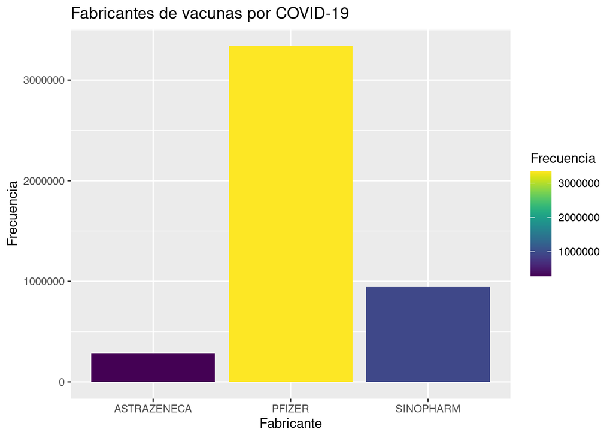

### DEPARTAMENTO

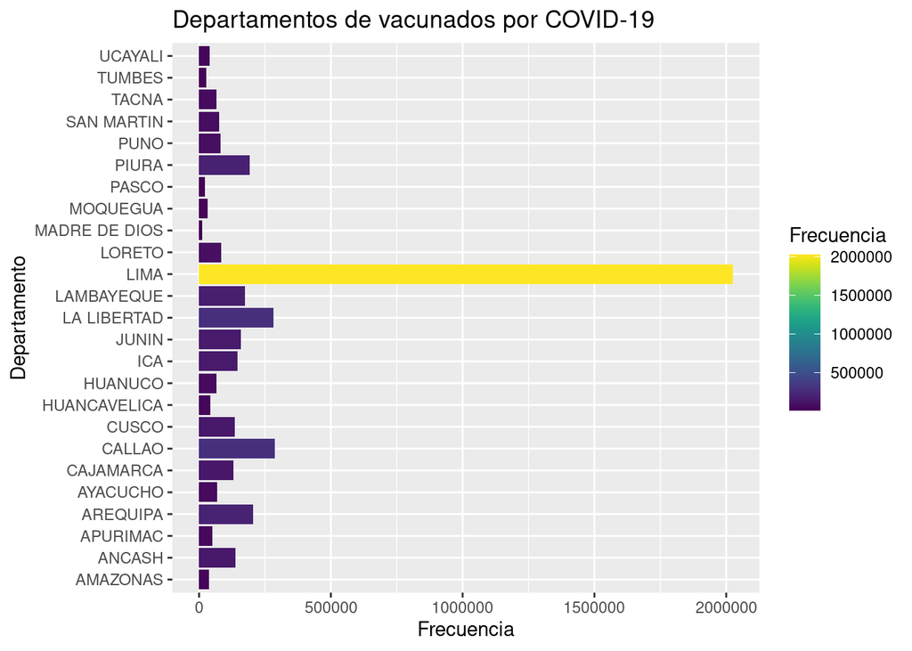

# Patrones y descripcion del conjunto de datos

```r
#
#
# CODE
#
#
max(DFVacunadosCLEAN$FECHA_VACUNACION)
```

```
## [1] "2021-06-08"
```

# Variables aleatorias

## Qué tan probable es que eligiendo una persona al azar de nuestra muestra, esta sea un adulto mayor de Lima y haya sido vacunado con el fabricante Pfizer. (No es equiprobable)

```r
E1<-(DFVacunadosCLEAN$GRUPO=="ADULTO MAYOR")
E2<-(DFVacunadosCLEAN$DEPARTAMENTO=="LIMA")
E3<-(DFVacunadosCLEAN$FABRICANTE=="PFIZER")

sum(E1&E2&E3)/nrow(DFVacunadosCLEAN)
```

```
## [1] 0.2734933
```

## Qué tan probable es que en UCAYALI exista un adulto mayor con 2 dosis y de género masculino

```r
E1<-(DFVacunadosCLEAN$DEPARTAMENTO == "UCAYALI")
E2<-(DFVacunadosCLEAN$GRUPO == "ADULTO MAYOR")
E3<-(DFVacunadosCLEAN$SEXO == "MASCULINO")
E4<-(DFVacunadosCLEAN$DOSIS == 2)
sum(E1&E2&E3&E4)/nrow(DFVacunadosCLEAN)
```

```
## [1] 0.0004066406
```

## Qué tan probable es que eligiendo una persona al azar esta sea una mujer y tenga 1 dosis

```r
E1<-(DFVacunadosCLEAN$SEXO=="FEMENINO")
E2<-(DFVacunadosCLEAN$DOSIS==1)

sum(E1&E2)/nrow(DFVacunadosCLEAN)
```

```
## [1] 0.3559801
```

## Qué tan probable es que el fabricante de una vacuna aplicada sea sinopharm

```r
E1 <- (DFVacunadosCLEAN$FABRICANTE=="SINOPHARM")
E2 <- nrow(DFVacunadosCLEAN)
round(sum(E1)/E2, digits=2)
```

```
## [1] 0.21
```

## Qué tan probable es que el género de una persona fallecida sea hombre

```r
E1 <- (DFFallecidosCLEAN$SEXO=="MASCULINO")
E2 <- nrow(DFFallecidosCLEAN)
round(sum(E1)/E2, digits=2)
```

```
## [1] 0.64
```

## Qué tan probable es que la etapa de vida de una persona fallecida sea adulto mayor(60 a más)

```r
E1 <- (DFFallecidosCLEAN$EDAD>=60)
E2 <- nrow(DFFallecidosCLEAN)
round(sum(E1,na.rm=TRUE)/E2, digits=2)
```

```
## [1] 0.7
```

# Hipótesis

## Dataset Fallecidos

### Fecha de fallecimiento

HIPÓTESIS: ¿Cómo influye la llegada de las vacunas en la cantidad de fallecidos por COVID? En lo que va la llegada de las vacunas, el pico más alto de la cantidad de fallecidos fue obtenido durante este periodo.

### Edad

HIPÓTESIS: ¿Será cierto que los adultos mayores son las personas que más fallecieron por COVID? El rango de edades de la mayor cantidad de personas que fallecieron por COVID está entre 60 y 80 años.

### Sexo

HIPÓTESIS: ¿Existe alguna diferencia entre la cantidad de fallecidos y su género? En el Perú, la gran mayoría de personas fallecidas por COVID son hombres.

### Departamento

HIPÓTESIS:¿Es cierto que los departamentos del Norte tienen la mayor cantidad de fallecidos por COVID? A partir de los gráficos, Lima es la ciudad con mayor cantidad de fallecidos por COVID

## Dataset Vacunados

### Sexo

HIPÓTESIS: ¿Es cierto que el género de la mayor cantidad de personas vacunadas es el mismo que de las personas fallecidas? No, observamos que la mayor cantidad de personas vacunadas son mujeres.

### Dosis

HIPÓTESIS:¿Existe la misma cantidad de dosis aplicadas en las personas vacunadas del Perú? No, la mayor cantidad de dosis aplicadas es la primera.

### Fabricante

HIPÓTESIS: ¿Será el mayor fabricante de vacunas del mundo (AstraZeneca) el que distribuye mayor cantidad de vacunas al Perú? El fabricante que más cantidad de vacunas distribuye al Perú es Pfizer.

### Departamento

¿Es cierto que el departamento con la mayor cantidad de personas vacunadas es el mismo que de las personas fallecidas? Si, es cierto que el departamento con mayor cantidad de personas vacunadas es Lima.

# Relaciones entre variables

## Primera relación

### Cantidad de fallecidos en la 2da ola por etapa de vida x Cantidad de vacunados en la 2da ola por etapa de vida

Utilities

Etapas de vida Niños(0-11 años) Adolescentes (12 - 17 años) Jóvenes(18 - 29 años) Adultos (30 -59 años) Adulto Mayor(60 a más)

Creamos dataset cantidad de fallecidos agrupados por etapa de vida

Para adultos mayores

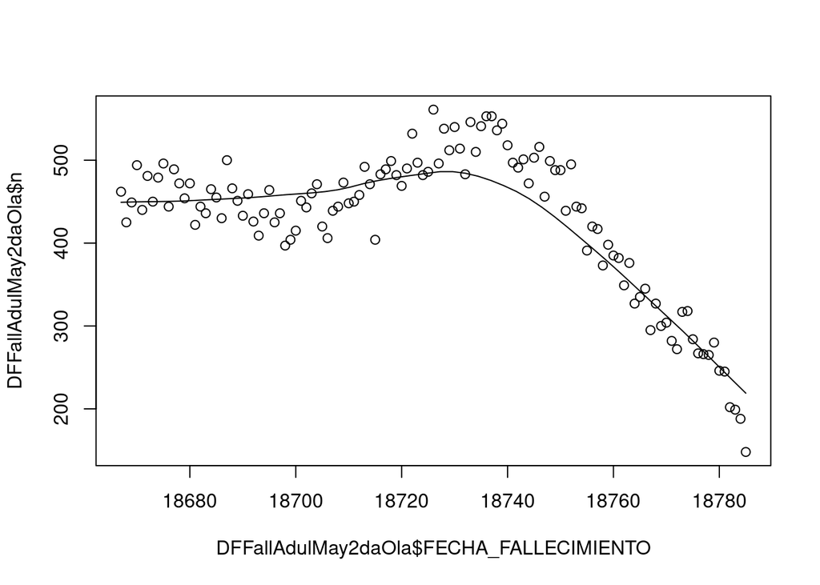

```r
scatter.smooth(x = DFFallAdulMay2daOla$FECHA_FALLECIMIENTO, y = DFFallAdulMay2daOla$n)
```

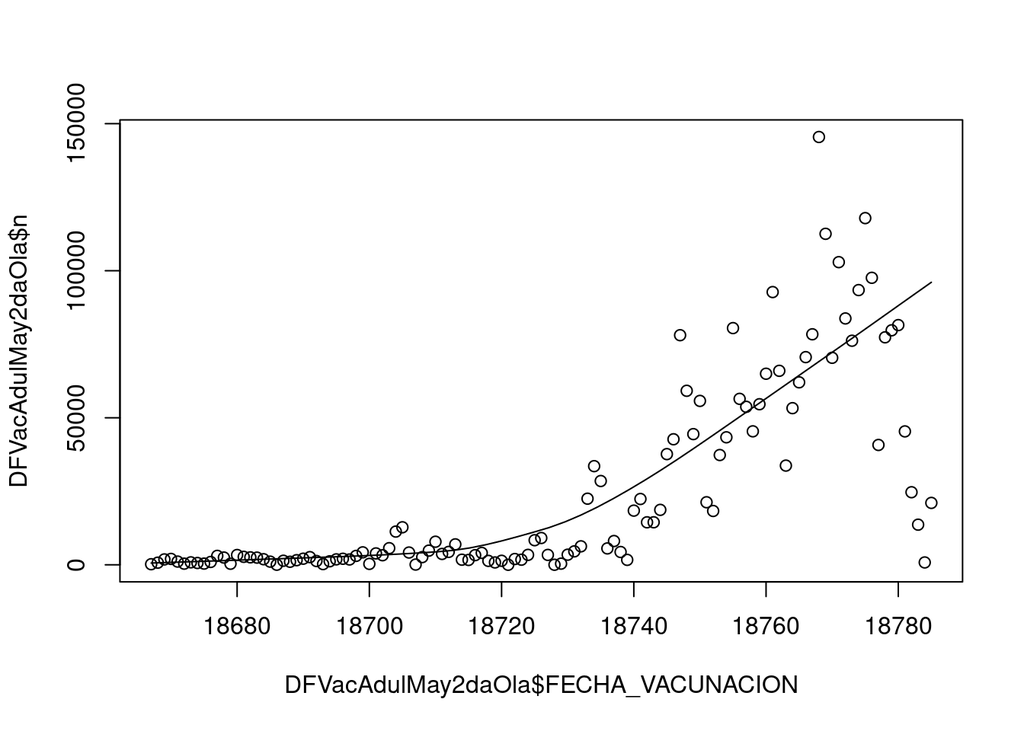

```r
scatter.smooth(x = DFVacAdulMay2daOla$FECHA_VACUNACION, y = DFVacAdulMay2daOla$n)
```

```r
cor(DFFallAdulMay2daOla$n, DFVacAdulMay2daOla$n)
```

```
## [1] -0.5704937
```

Para adultos

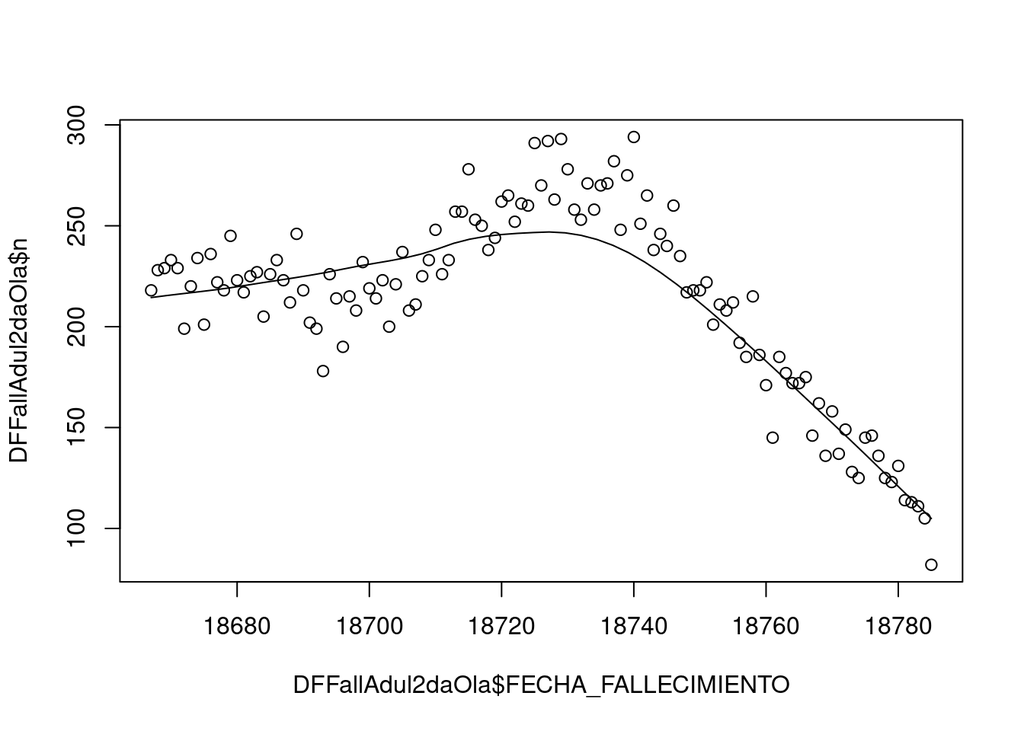

```r
scatter.smooth(x = DFFallAdul2daOla$FECHA_FALLECIMIENTO, y = DFFallAdul2daOla$n)
```

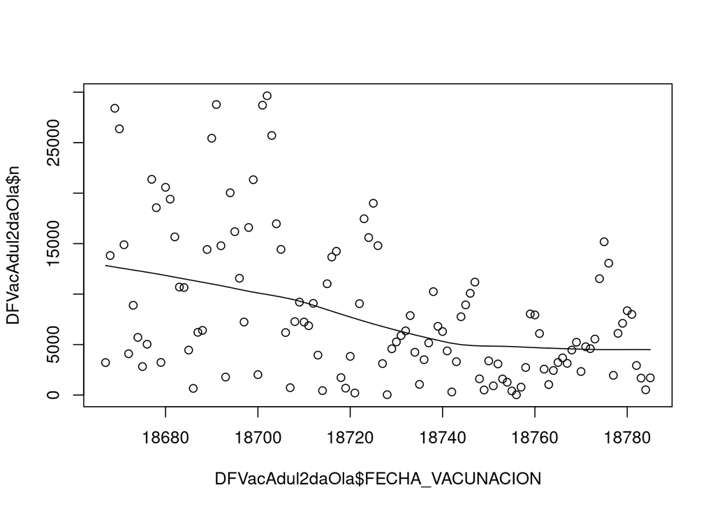

```r
scatter.smooth(x = DFVacAdul2daOla$FECHA_VACUNACION, y = DFVacAdul2daOla$n)
```

```r
cor(DFFallAdul2daOla$n, DFVacAdul2daOla$n)
```

```
## [1] 0.1306875
```

Para jovenes

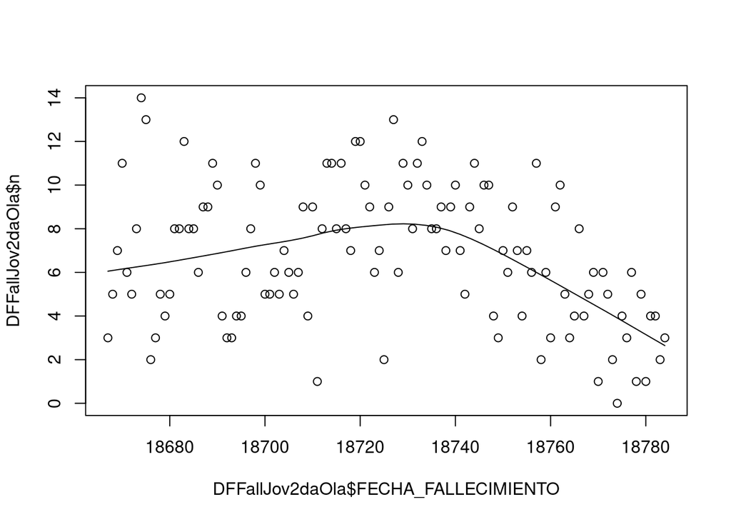

```r
scatter.smooth(x = DFFallJov2daOla$FECHA_FALLECIMIENTO, y = DFFallJov2daOla$n)
```

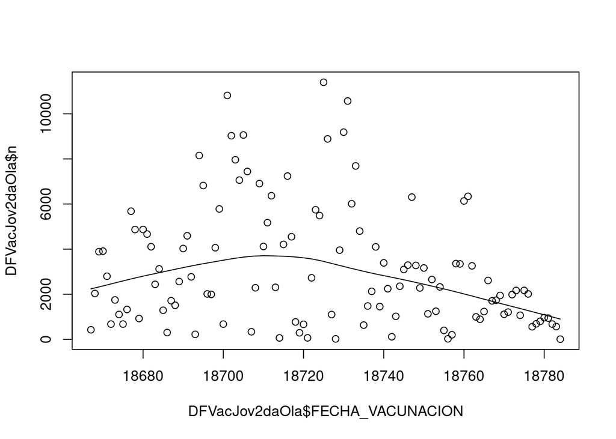

```r
scatter.smooth(x = DFVacJov2daOla$FECHA_VACUNACION, y = DFVacJov2daOla$n)
```

```r
cor(DFFallJov2daOla$n, DFVacJov2daOla$n)
```

```
## [1] 0.04970341
```

## Segunda relación

### Cantidad de fallecidos por departamento en la 2da ola x Cantidad de vacunados por departamento en la 2da ola en el departamento con más vacunados

Calculamos las regiones más vacunados

```
##
##      AMAZONAS        ANCASH      APURIMAC      AREQUIPA      AYACUCHO
##         38059        136811         49402        203998         68095
##     CAJAMARCA        CALLAO         CUSCO  HUANCAVELICA       HUANUCO
##        130355        287418        135399         41721         64805
##           ICA         JUNIN   LA LIBERTAD    LAMBAYEQUE          LIMA
##        145645        157707        280935        173348       2025091
##        LORETO MADRE DE DIOS      MOQUEGUA         PASCO         PIURA
##         83494         11803         32011         23314        191276
##          PUNO    SAN MARTIN         TACNA        TUMBES       UCAYALI
##         80436         76989         66323         27313         39856
```

```
## LIMA
##   15
```

Vemos que Lima es el departamento que tiene más vacunados, y Madre de Dios es que el tiene menos vacunados.

Para Lima

```r
# Calculamos fallecidos por departamento
DFFallecidosCLEAN %>% select(DEPARTAMENTO, FECHA_FALLECIMIENTO) %>%
  filter(DEPARTAMENTO =="LIMA METROPOLITANA" | DEPARTAMENTO == "LIMA REGION") %>%
  filter(FECHA_FALLECIMIENTO >= as.Date("2021-02-09")) -> fall2daOlaLima
DFfall2daOlaLima <- as.data.frame(table(fall2daOlaLima$FECHA_FALLECIMIENTO),
                              col.names = c("FECHAS", "CANT_FALLECIDOS"))


# Calculamos vacunados por departamento
DFVacunadosCLEAN %>% select(DEPARTAMENTO, FECHA_VACUNACION) %>%
  filter(DEPARTAMENTO =="LIMA") %>%
  filter(FECHA_VACUNACION >= as.Date("2021-02-09") &
         FECHA_VACUNACION <= as.Date("2021-06-07")) -> vac2daOlaLima
DFvac2daOlaLima <- as.data.frame(table(vac2daOlaLima$FECHA_VACUNACION),
                              col.names = c("FECHAS", "CANT_VACUNADOS"))
cor(DFvac2daOlaLima$Freq, DFfall2daOlaLima$Freq)
```

```
## [1] -0.4668205
```

Distribución de los vacunados y fallecidos en Lima en la segunda Ola

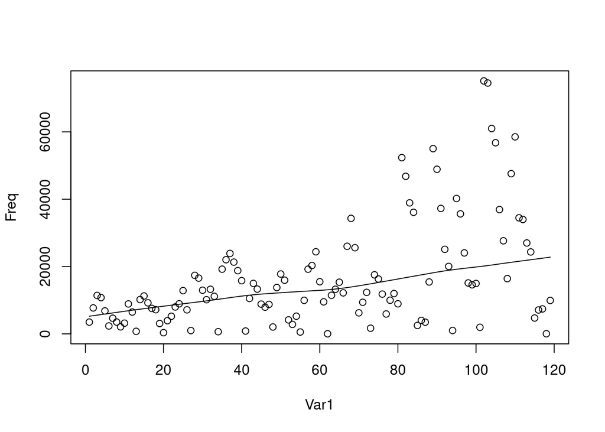

```r
# TODO arreglar grafica para que se vean las dos juntas
scatter.smooth(DFvac2daOlaLima)
```

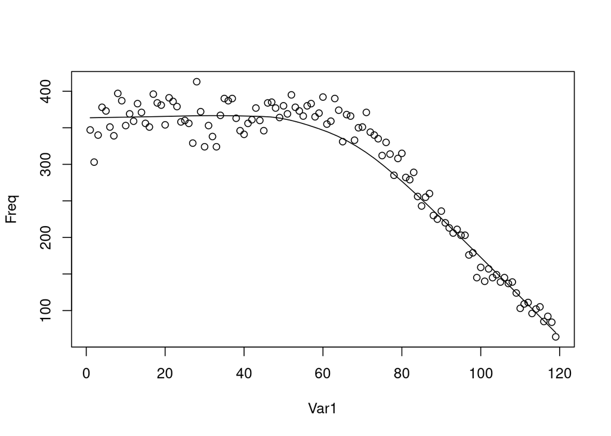

```r
scatter.smooth(DFfall2daOlaLima)
```

## Tercera relación

### Cantidad de fallecidos por departamento en la 2da ola x Cantidad de vacunados por departamento en la 2da ola en el departamento con menos vacunados

```
##
##      AMAZONAS        ANCASH      APURIMAC      AREQUIPA      AYACUCHO
##         38059        136811         49402        203998         68095
##     CAJAMARCA        CALLAO         CUSCO  HUANCAVELICA       HUANUCO
##        130355        287418        135399         41721         64805
##           ICA         JUNIN   LA LIBERTAD    LAMBAYEQUE          LIMA
##        145645        157707        280935        173348       2025091
##        LORETO MADRE DE DIOS      MOQUEGUA         PASCO         PIURA
##         83494         11803         32011         23314        191276
##          PUNO    SAN MARTIN         TACNA        TUMBES       UCAYALI
##         80436         76989         66323         27313         39856
```

```
## MADRE DE DIOS
##            17
```

Vemos que Madre de Dios es el departamento que menos vacunados.

Para Madre de Dios

```r
# Calculamos fallecidos por departamento
DFFallecidosCLEAN %>% select(DEPARTAMENTO, FECHA_FALLECIMIENTO) %>%
  filter(DEPARTAMENTO =="MADRE DE DIOS") %>%
  filter(FECHA_FALLECIMIENTO >= as.Date("2021-02-09") &
           FECHA_FALLECIMIENTO <= as.Date("2021-06-03") ) -> fall2daOlaMadDios
DFfall2daOlaMadDios <- as.data.frame(table(fall2daOlaMadDios$FECHA_FALLECIMIENTO),
                              col.names = c("FECHAS", "CANT_FALLECIDOS"))

# Limpiamos los datos
s <- as.Date("2021-02-11")
e <- as.Date("2021-06-03")
daysCompleteMadDios <- seq(from=s, to=e, by=1)
fallCompleteMadDios <- c()
theDate <- s
while (theDate <= e){
  toSearch <- grep(theDate, DFfall2daOlaMadDios$Var1)
  if(!fun_int0(toSearch)){
    fallCompleteMadDios <- c(fallCompleteMadDios, 0)
  } else {
    fallCompleteMadDios <- c(fallCompleteMadDios, DFfall2daOlaMadDios$Freq[toSearch])
  }
  theDate <- theDate + 1
}
# dataset final de vacunados en la segunda ola completo
DFfall2daOlaMadDiosComplete <- data.frame(FECHAS=daysCompleteMadDios,
                                          CANTIDAD=fallCompleteMadDios)

# Calculamos vacunados por departamento
DFVacunadosCLEAN %>% select(DEPARTAMENTO, FECHA_VACUNACION) %>%
  filter(DEPARTAMENTO =="MADRE DE DIOS") %>%
  filter(FECHA_VACUNACION >= as.Date("2021-02-09") &
         FECHA_VACUNACION <= as.Date("2021-06-03")) -> vac2daOlaMadDios
DFvac2daOlaMadDios <- as.data.frame(table(vac2daOlaMadDios$FECHA_VACUNACION),
                              col.names = c("FECHAS", "CANT_VACUNADOS"))

# Limpiamos los datos
s <- as.Date("2021-02-11")
e <- as.Date("2021-06-03")
daysCompleteMadDios <- seq(from=s, to=e, by=1)
vacCompleteMadDios <- c()
theDate <- s
while (theDate <= e){
  toSearch <- grep(theDate, DFvac2daOlaMadDios$Var1)
  if(!fun_int0(toSearch)){
    vacCompleteMadDios <- c(vacCompleteMadDios, 0)
  } else {
    print(DFvac2daOlaMadDios$Freq[toSearch])
    vacCompleteMadDios <- c(vacCompleteMadDios, DFvac2daOlaMadDios$Freq[toSearch])
  }
  theDate <- theDate + 1
}
```

```
## [1] 149
## [1] 174
## [1] 46
## [1] 9
## [1] 92
## [1] 66
## [1] 617
## [1] 259
## [1] 144
## [1] 21
## [1] 27
## [1] 21
## [1] 57
## [1] 8
## [1] 6
```

[output cut: 73 more lines]

```r
# dataset final de vacunados en la segunda ola completo
DFvac2daOlaMadDiosComplete <- data.frame(FECHAS=daysCompleteMadDios,
                                          CANTIDAD=vacCompleteMadDios)

cor(DFfall2daOlaMadDiosComplete$CANTIDAD, DFvac2daOlaMadDiosComplete$CANTIDAD)
```

```
## [1] -0.1124028
```

Distribución de los vacunados y fallecidos en Madre de Dios en la segunda Ola

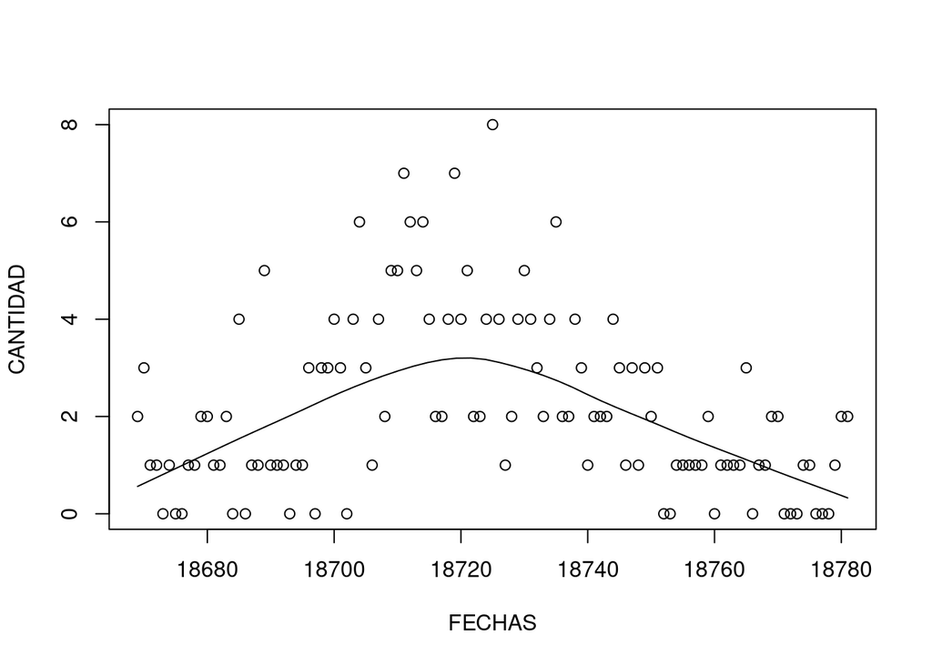

```r
# TODO arreglar grafica para que se vean las dos juntas
scatter.smooth(DFfall2daOlaMadDiosComplete)
```

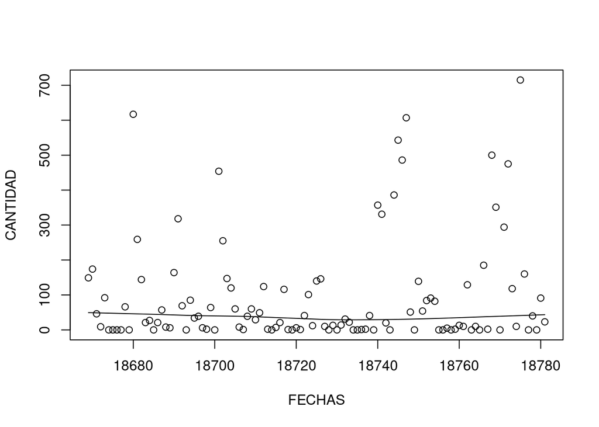

```r
scatter.smooth(DFvac2daOlaMadDiosComplete)
```